# Association rules

Movie recommender systems

Mobin Asri 93101938

2018-07-21 00:01:43

> با استفاده از داده نظرهای فیلم به سوالات زیر پاسخ دهید.

```r
library(dplyr)
library(stringr)
library(readr)
library(stringr)
library(ggplot2)
library(highcharter)
library(tidyr)
```

```r
movie = read_delim("../../Week12/ml-10M100K/movies.dat",delim = "::",
                   col_names = c("MovieID",NA,"Title",NA,"Genres"))
movie = movie %>% select(1,3,5)

tag = read_delim("../../Week12/ml-10M100K/tags.dat",delim="::",
                 col_names = c("UserID",NA,"MovieID",NA,"Tag",NA,"Timestamp"))
tag = tag %>% select(1,3,5,7)

rating=read_delim("../../Week12/ml-10M100K/ratings.dat",delim="::",
                  col_names = c("UserID",NA,"MovieID",NA,"Rating",NA,"Timestamp"))
rating=rating %>% select(1,3,5,7)
```

۱. آماره های زیر را بیابید. الف. محبوب ترین فیلم کدام است؟

```r
rating %>%
  filter(Rating>4) %>%
  group_by(MovieID) %>%
  summarise(totRating=sum(Rating)) %>%
  inner_join(movie) %>%
  arrange(desc(totRating)) -> topMovies
```

```r
topMovies %>%
  slice(1:10) %>%
  hchart(hcaes(x=Title,totRating),type="column")
```

[interactive chart not shown]

ب. بیشترین نظرات درباره چه فیلمی داده شده است؟

```r
tag %>%
  group_by(MovieID) %>%
  summarise(count=n()) %>%
  inner_join(movie) %>%
  arrange(desc(count)) -> topTag
```

```r
topTag %>%
  slice(1:10) %>%
  hchart(hcaes(x=Title,y=count),type="column")
```

[interactive chart not shown]

پ. منفورترین فیلم کدام است؟

```r
rating %>%
  filter(Rating<=2) %>%
  group_by(MovieID) %>%
  summarise(totRating=sum(Rating)) %>%
  inner_join(movie) %>%
  arrange(totRating) -> WorstMovies
```

```r
WorstMovies %>%
  slice(1:10) %>%
  hchart(hcaes(x=Title,totRating),type="column")
```

[interactive chart not shown]

ت. تعداد فیلم های ساخته شده در هر سال

```r
movie %>%
  mutate(year=str_extract(Title,pattern = "\\((\\d){4}\\)")) -> movie

movie %>%
  filter(!is.na(year) ) %>%
  group_by(year) %>%
  summarise(count=n()) %>%
  arrange(desc(count))-> topYear

topYear %>%
  slice(1:10) %>%
  hchart(hcaes(x=year,y=count),type="column")
```

[interactive chart not shown]

ث. در هر سالی مردم به چه ژانری علاقه مند بوده اند.

```r
str_split_fixed(movie$Genres  ,pattern = "\\|",n=10) -> t
movie_g = cbind(movie,t)
movie_g %>% gather(order,Genre,5:14) -> movie_g
movie_g[,-3] %>%
  filter(Genre !="") -> movie_g

movie_g %>%
  inner_join(rating) -> GenreRating
```

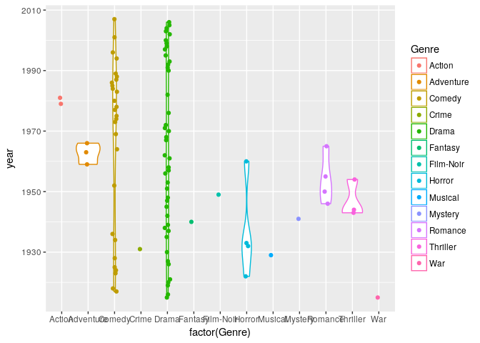

```r
GenreRating %>%
  select(year,Genre) %>%
  group_by(year,Genre) %>%
  summarise(count=n()) %>%
  group_by(year) %>%
  filter(Genre != "") %>%
  top_n(wt = count,n=1) %>%
  ungroup() %>%
  mutate(year=str_extract(year,pattern = "\\d{4}"))-> YearGenre

YearGenre$year = as.numeric(YearGenre$year)

YearGenre %>%
  filter(!is.na(year)) %>%
  ggplot(aes(factor(Genre),year,colour=Genre))+
  geom_violin() + geom_jitter(height = 0, width = 0.1)
```

***

۲. ژانر فیلم ها را استخراج نمایید. سپس آماره های زیر را استخراج نمایید. الف. نمودار ستونی تعداد فیلم های هر ژانر

```r
movie_g %>%
  group_by(Genre) %>%
  summarise(count=n()) %>%
  filter(count > 1)-> GenreCount

GenreCount %>%
  arrange(desc(count)) %>%
  slice(1:10) %>%
  hchart(hcaes(x=Genre,y=count),type="column")
```

[interactive chart not shown]

```r
GenreRating %>%
  group_by(Genre) %>%
  summarise(meanRate=mean(Rating,na.rm=T),
            count=n()) %>%
  filter(count>20000)-> OverllRate

OverllRate %>%
  arrange(desc(meanRate)) %>%
  slice(1:10) %>%
  hchart(hcaes(x=Genre,y=meanRate),type="column")
```

[interactive chart not shown]

۳. نمودار ابر لغات را بر حسب کلمات عنوان فیلم ها رسم نمایید.

```r
library(RColorBrewer)
library(wordcloud2)
library(tm)
library(wordcloud2)
```

```r
Titles=str_sub(movie$Title,start = 1,end = -8)
Titles %>% unique() -> Titles
Titles %>%
  str_split(" ") %>%
  unlist() %>%
  str_to_lower() %>%
  str_replace(pattern = "[[:punct:]]|[[:blank:]]",replacement="") %>%
  removeWords(., stopwords('en')) %>%
  removeWords(., stopwords('fr')) %>%
  table() %>%  as.data.frame() -> wordFreq

colnames(wordFreq)=c("word","freq")

wordFreq$word = as.character(wordFreq$word)
```

```r
wordFreq %>%
  arrange(desc(freq)) %>%
  filter(freq > 10,nchar(word) >=3 ) -> wordFreq
wordFreq[c(-1,-2),] -> wordFreq
```

```r
wordcloud2(wordFreq, size = 2, minRotation = -pi/6, maxRotation = -pi/6,
             rotateRatio = 1)
```

[interactive chart not shown]

```r
library(arules)
rating %>%
  filter(Rating >= 4) %>%
  inner_join(movie) %>%
  group_by(UserID) %>%
  distinct(Title)-> mydf
ss <- split.data.frame(mydf,mydf$UserID)
mylist=lapply(ss,"[[","Title")

trans=as(mylist,"transactions")
```

```r
grules = apriori(trans, parameter = list(support = 0.009,
                                             confidence = 0.25, minlen = 2))
```

```
## Apriori
##
## Parameter specification:
##  confidence minval smax arem  aval originalSupport maxtime support minlen
##        0.25    0.1    1 none FALSE            TRUE       5   0.009      2
##  maxlen target   ext
##      10  rules FALSE
##
## Algorithmic control:
##  filter tree heap memopt load sort verbose
##     0.1 TRUE TRUE  FALSE TRUE    2    TRUE
##
## Absolute minimum support count: 628
##
## set item appearances ...[0 item(s)] done [0.00s].
## set transactions ...[9485 item(s), 69794 transaction(s)] done [0.62s].
## sorting and recoding items ... [1488 item(s)] done [0.11s].
## creating transaction tree ... done [0.05s].
## checking subsets of size 1 2 3
```

```
##  done [10.88s].
## writing ... [3964176 rule(s)] done [0.63s].
## creating S4 object  ... done [0.50s].
```

```r
movierules = subset(grules, lhs %in% "Castle in the Sky (Tenkû no shiro Rapyuta) (1986)")
inspect(sort(movierules, by = "lift"))
```

```
##     lhs                                                    rhs                                                        support confidence      lift count
## [1] {Castle in the Sky (Tenkû no shiro Rapyuta) (1986)} => {Spirited Away (Sen to Chihiro no kamikakushi) (2001)} 0.010058171  0.8239437 15.141212   702
## [2] {Castle in the Sky (Tenkû no shiro Rapyuta) (1986)} => {Lord of the Rings}                                    0.009742958  0.7981221  3.722045   680
## [3] {Castle in the Sky (Tenkû no shiro Rapyuta) (1986)} => {Star Wars}                                            0.009112531  0.7464789  1.764717   636
```

```r
movierules = subset(grules, lhs %in% "Cast Away (2000)")
inspect(sort(movierules, by = "lift")[1:10])
```

```
##      lhs                                                                                                 rhs                                                                                                  support confidence      lift count
## [1]  {Cast Away (2000),
##       Harry Potter and the Chamber of Secrets (2002)}                                                 => {Harry Potter and the Sorcerer's Stone (a.k.a. Harry Potter and the Philosopher's Stone) (2001)} 0.011003811  0.8600224 14.795268   768
## [2]  {Cast Away (2000),
##       Harry Potter and the Sorcerer's Stone (a.k.a. Harry Potter and the Philosopher's Stone) (2001)} => {Harry Potter and the Chamber of Secrets (2002)}                                                 0.011003811  0.6421405 14.155891   768
## [3]  {Bourne Identity, The (2002),
##       Cast Away (2000)}                                                                               => {Bourne Supremacy, The (2004)}                                                                   0.010373385  0.5223665 12.040307   724
## [4]  {Bourne Supremacy, The (2004),
##       Cast Away (2000)}                                                                               => {Bourne Identity, The (2002)}                                                                    0.010373385  0.8379630 11.456374   724
## [5]  {Cast Away (2000),
##       Spider-Man 2 (2004)}                                                                            => {Spider-Man (2002)}                                                                              0.010445024  0.8010989 10.234651   729
## [6]  {Cast Away (2000),
##       Spider-Man (2002)}                                                                              => {Spider-Man 2 (2004)}                                                                            0.010445024  0.4847074  9.431188   729
## [7]  {Cast Away (2000),
##       X2}                                                                                             => {Spider-Man (2002)}                                                                              0.009914892  0.7185877  9.180508   692
## [8]  {Cast Away (2000),
##       Lock, Stock & Two Smoking Barrels (1998)}                                                       => {Snatch (2000)}                                                                                  0.009399089  0.6986155  9.066414   656
## [9]  {Bourne Identity, The (2002),
##       Cast Away (2000)}                                                                               => {Catch Me If You Can (2002)}                                                                     0.011476631  0.5779221  9.033705   801
## [10] {Cast Away (2000),
##       There's Something About Mary (1998)}                                                            => {Meet the Parents (2000)}                                                                        0.009771614  0.4806202  9.014889   682
```

۵. تمرین سخت: در گیت هاب برای خود اکانت درست کنید. همه تمرین های خود را آنجا بارگذاری کنید! و لینک آن را ارسال نمایید.

https://github.com/e2this/DataAnalysisCourse

۶. پنج انتقاد از درس و نحوه تدریس را بیان کنید.

۷. پنج پیشنهاد برای بهتر شدن درس بیان کنید.

۱. تمرین ها از نظر مطابقت با مطالب تدریس شده سر کلاس به خوبی تنظیم شده بود ولی از نظر حجم به نظرم هر تمرین با حجم کمتر می تواند بهتر مطالب ارایه شده را مورد سوال قرار دهد. چرا که کار با داده نیازمند فکر و تحلیل و امتجان کردن رویکرد های مختلف است و حجم بالای هر تمرین مانع از این مهم می شود و کمیت در اولویت قرار می گیرد.

۲. زبان دیگر برنامه نویسی نیز می تواند در طول درس مورد استفاده قرار گیرد زیرا برای انجام بعضی کار ها برروی داده نیازمند استفاده از سایر زبان های برنامه نویسی هستیم.

۳. کار با داده های حجیم به نظرم باید بیشتر مورد توجه قرار گیرد زیرا امروزه حجم بالای داده در بسیاری از موارد مشکل ساز است.

۸. سه موضوع آماری جدید برای جایگزینی در سرفصل ها پیشنهاد دهید.

۱. کار با داده های زیستی که انواع مختلفی دارد برای مثال داده های میکرو آرایه ها

۲. داده های شرط بندی و بررسی اینکه آیا واقعا مراکز شرط بندی بر اساس شانس اداره می شوند یا نه

۳. Simpson’s Paradox

۹. سه داده جالب برای کار در کلاس پیشنهاد دهید.

۱. داد های بیان ژن و بررسی ژن های موثر در یک بیماری

۱۰. چهار نکته مهمی که در کلاس یاد گرفتید را بیان کنید.

۱. استفاده از پکیج dply و tidyverse

۲. تصویرسازی نتایج با استفاده از پکیج های ggplot و highcharter

۳. یکی از مهم کار ها قبل از این که آنالیز داده را شروع کنیم شناخت کامل داده است.

۴. نتایج آنالیز را به گونه ای نمایش ندهیم تا آنچه که واقعیت ندارد ولی چون دلخواه ماست نشان داده شود.